# 06 Interés Compuesto.

2024-02-19

## Tema 2: Interés Compuesto.

## Tema 2.4: Introducción al Interés Compuesto.

- El interés compuesto toma en cuenta lo que crece la deuda o la inversión sobre el interés generado.
- Es decir, el interés generado se multiplica.

Por ejemplo, imagina el principal o valor inicial \(P\), en cada periodo, \(t\), tomando en cuenta un interés \(r\), y su valor final \(A_t\):

- Primer periodo \(A_1\) \[A_1= P(1+r)\]

¿Pero qué pasa en el segundo periodo?

## Tema 2.4: Introducción al Interés Compuesto.

- Segundo periodo \(A_2\) \[A_2= A_1(1+r)\]
- Tercer periodo \(A_3\) \[A_3= A_2(1+r)\]

Substituyendo \(A_2=A_1(1+r)\): \[A_3= A_1(1+r)(1+r)\]

Substituyendo \(A_1=P(1+r)\): \[A_3= P(1+r)(1+r)(1+r)\]

## Tema 2.4: Introducción al Interés Compuesto.

¿Cuál es la fórmula general?

- Es evidente que en cada periodo, va a crecer el 100% del valor anterior más la tasa de interés \(r\)
- Es decir, en cada periodo, \(t\), el \(P\) se multiplica por \((1+r)\) (recuerda la progresión geométrica)

El interés compuesto es: \[A_n= P(1+r)^t\]

## Tema 2.4: Introducción al Interés Compuesto.

Pero, ¿qué pasa si la capitalización del interés no es anual, sino trimestral, bimestral o semestral?

- Recordando, si el interés es anual, y se capitaliza trimestralmente: \[r/4\]
- ¿Y cuántas veces se va a capitalizar? \[4*t\]

Es decir 4 veces por año.

## Tema 2.4: Introducción al Interés Compuesto.

¿Cómo se ajustaría la fórmula para la capitalización trimestral por 5 años a interés anual?

- Pues, comenzamos por remplazar el interés tomando en cuenta el periodo de capitalización trimestral \[A_t= P(1+r/4)^t\]
- Ahora tomemos en cuenta que en \(t=5\) años se va a capitalizar \(n=4\) veces en un año.
- ¡Es decir, \(P\) se va a multiplicar por \((1+r/4)\), \(4*5=20\) veces!

## Tema 2.4: Introducción al Interés Compuesto.

En la fórmula:

\[A_t= P(1+r/4)^{4*5}\]

Y generalizando, el interés compuesto capitalizado:

\[A_t= P(1+r/n)^{nt}\]

Donde:

- \(P\) es el capital inicial o principal y \(r\) es la tasa de interés anual.
- \(n\) es el número de veces que se capitaliza el interés por año y \(t\) es el número total de años.

## Tema 2.4: Introducción al Interés Compuesto.

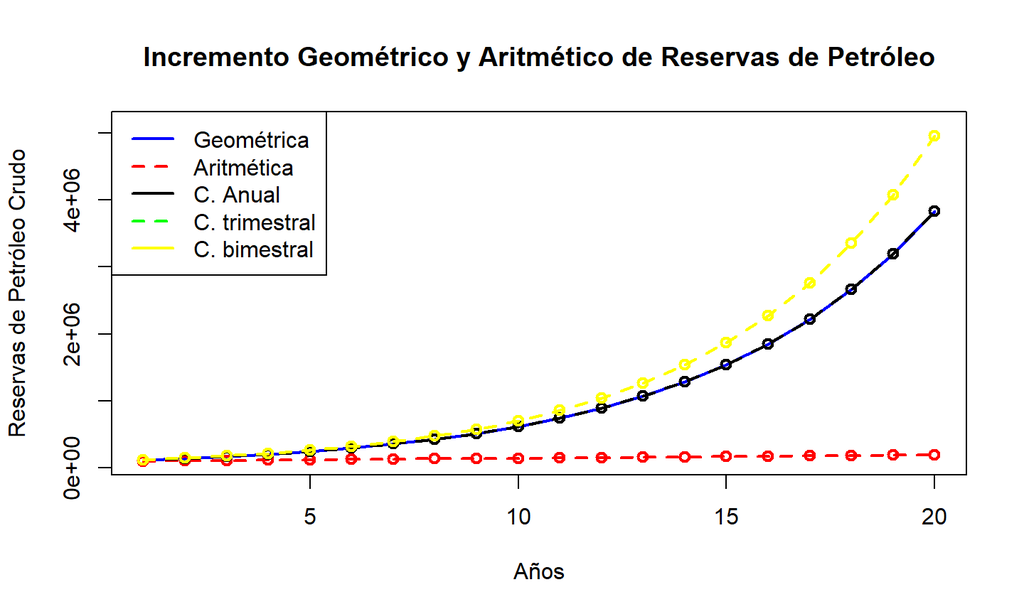

## Tema 2.4: Introducción al Interés Compuesto.

- Cuando interés compuesto se capitaliza anualmente, entonces es una serie geométrica.

\[S_n = S_0*r^t\]

- Recordemos, si crece al 20% anual, entonces \(r=(1+.20)\),

\[S_n = S_0*(1+.20)^t\]

- Substituyendo \(S_0=P\) \[S_n = P*(1+.20)^t\]

## Tema 2.4: Ejemplo (1/1)

- Supón que requieres un capital semilla de \(100,000\) pesos para abrir un negocio.
- Si tu crédito es del 10% compuesto anual por 5 años.

¿Cuál es valor vencimiento de tu crédito?

## Tema 2.4: Ejemplo (1/2)

Usando la fórmula de interés compuesto: \[A_n= P(1+r)^t\]

Substituyendo: \[A_5= 100000(1+.1)^5\]

```r
100000*(1+.1)^5
```

```
## [1] 161051
```

¿Cuánto fue el interés generado en los 5 años?

## Tema 2.4: Ejemplo (1/3)

El interés generado: \[I=A-P\]

Substituyendo: \[I=161,051-100,000\]

```r
161051-100000
```

```
## [1] 61051
```

## Tema 2.4: Ejemplo (2/1)

- Se hizo un préstamo inicial de \(60,000.00\) pesos.
- El valor de vencimiento es de \(150,000\) pesos después de 4 años y se aplicó el interés compuesto. ¿Cuál fue la tasa de interés del préstamo?

## Tema 2.4: Ejemplo (2/2)

Usando la fórmula de interés compuesto:

\[A_4= 60,000(1+r)^4\]

Si \(A_4=150,000\)

\[150,000= 60,000(1+r)^4\]

Despejando, paso 1: \[150,000/60,000= (1+r)^4\]

## Tema 2.4: Ejemplo (2/3)

Despejando, paso 2: \[(150,000/60,000)^{1/4}= (1+r)\]

Despejando, paso 3: \[(150,000/60,000)^{1/4}-1= r)\]

```r
(150000/60000)^(1/4)-1
```

```
## [1] 0.2574334
```

\[r=25.74\%\]

## Tema 2.4: Ejemplo (3/1)

- El valor final de un préstamo alcanzó los \(275,000.00\) pesos a una tasa de interés simple compuesto del \(20%\).
- Y, el interés generado ascendió a \(155,000\) pesos.

¿En cuántos años se liquidó la deuda?

## Tema 2.4: Ejemplo (3/2)

Usando la fórmula de interés compuesto:

\[A_t= P(1+.20)^t\]

Si \(A_t=275,000\)

\[275,000= P(1+.20)^t\]

Despejando, paso 1, si \(I=A-P\): \[P=A-I\] Entonces: \[P=275,000-155,000\]

```r
275000-155000
```

```
## [1] 120000
```

## Tema 2.4: Ejemplo (3/3)

Despejando, paso 2 \[275,000/120,000= (1+.20)^t\]

Despejando, paso 3 \[log(275,000/120,000)= log((1+.20)^t)\]

Donde: \[log(275,000/120,000)= t*log((1+.20))\]

## Tema 2.4: Ejemplo (3/4)

Despejando, paso 4 \[log(275,000/120,000)/log((1+.20))= t\]

```r
log(275000/120000)/log((1+.20))
```

```
## [1] 4.548444
```

4 años y 6 meses aproximadamente.

## Tema 2.4: Ejemplo (4/1)

- Invertiste \(100,000\) pesos en Certificados de la Tesorería de la Federación (CETES) a \(364\) días.
- A una tasa de interés compuesto anual de \(11.21\%\). ¿Cuál es el monto de tu inversión después de 5 años? ¿Cuál fue el interés generado? ¿Cuál fue el rendimiento total de la inversión?

## Tema 2.4: Ejemplo (4/2)

Usando la fórmula de interés compuesto:

\[A_t= 100,000(1+.1121)^5\]

```r
100000*(1+.1121)^5
```

```
## [1] 170105.8
```

El interés generado: \[I=A-P\]

Substituyendo: \[I=170,105.8-100,000\]

```r
170105.8-100000
```

```
## [1] 70105.8
```

## Tema 2.4: Ejemplo (4/3)

El rendimiento en los 5 años:

\[ \text{Rendimiento porcentual} = \frac{\text{valor final} - \text{valor inicial}}{\text{valor inicial}} \times 100 \]

Es decir: \[ \text{Rendimiento porcentual} = \frac{I}{P} \times 100 \]

```r
(170105.8-100000)/100000*100
```

```
## [1] 70.1058
```

- La inversión creció un 70.1% del valor inicial (\(100,000\)) pesos.

## Revisión

## Revisión

```
## Versión: 19/02/2024
```

## Bibliografía

## Bibliografía

- Petters, A. O., & Dong, X. (2016). An introduction to mathematical finance with applications. New York, NY: Springer, 10,978-1.
- Clendenen, G., & Salzman, S. A. (2014). Business Mathematics. Pearson Education.